# Stroke

#### 2.1.4.2 Harmonisation algorithm

To compute `stroke` from the study-specific variable it has to be recoded as follows:

- `hedimst == 1 into 1`
- `hedimst == -9 into 997`
- `hedimst == -8 into 998`
- `hedimst == 0 into 0`

To compute `stroke_age` from the study-specific variable it has to be recoded as follows:

- `if stroke == 1, stroke_age = heagery-ybirth`
- `if stroke == 0, stroke_age = 996`
- `-9 into 997`
- `-8 into 998`
- `-2 into 991`
- `-1 into 996`
- `otherwise, stroke_age = 999`

**R script:**

```r
# Categorical variable harmonization
ELSA_ds_w4 <- tibble(id = ELSA_w4$id)
ELSA_ds_w4$stroke <- car::recode(ELSA_w4$hedimst, "-8=998;-9=997")

# Continuous variable harmonization
ELSA_ds_w4$stroke_age <- rep(999, length(ELSA_w4$id))
ELSA_ds_w4$stroke_age[which(ELSA_ds_w4$stroke == 0)] <- 996
ELSA_ds_w4$stroke_age[which(ELSA_ds_w4$stroke == 1 & !ELSA_w4$heagery %in% c(-1,
    -8, -9, -2))] <- ELSA_w4$heagery[which(ELSA_ds_w4$stroke == 1 & !ELSA_w4$heagery %in%
    c(-1, -8, -9, -2))] - ELSA_w4$ybirth[which(ELSA_ds_w4$stroke == 1 & !ELSA_w4$heagery %in%
    c(-1, -8, -9, -2))]
ELSA_ds_w4$stroke_age <- car::recode(ELSA_ds_w4$stroke_age, "-1=996;-8=998;-9=997;-2=991;NA=999")
```

#### 2.1.4.3 Statistics of the new harmonized variable

Stroke

| Sample size | Missing values |
| --- | --- |
| 11050 | 16 |

Category

|  | 0 | 1 |
| --- | --- | --- |
| Frequency | 10851.0 | 183.00 |
| Percentage | 98.2 | 1.66 |

Type of missing

|  | 991 | 992 | 993 | 994 | 995 | 996 | 997 | 998 | 999 | NA |
| --- | --- | --- | --- | --- | --- | --- | --- | --- | --- | --- |
| Frequency | 0 | 0 | 0 | 0 | 0 | 0 | 7.00 | 9.00 | 0 | 0 |
| Percentage | 0 | 0 | 0 | 0 | 0 | 0 | 0.06 | 0.08 | 0 | 0 |

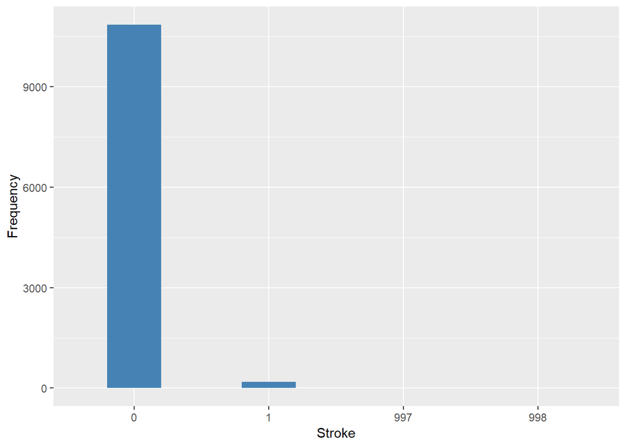

Age of each episode of stroke

| Sample size | Missing values |
| --- | --- |
| 11050 | 10955 |

Values

|  | No-missings | 991 | 992 | 993 | 994 | 995 | 996 | 997 | 998 | 999 | NA |
| --- | --- | --- | --- | --- | --- | --- | --- | --- | --- | --- | --- |
| Frequency | 95.00 | 0 | 0 | 0 | 0 | 0 | 10851.0 | 0 | 0 | 104.00 | 0 |
| Percentage | 0.86 | 0 | 0 | 0 | 0 | 0 | 98.2 | 0 | 0 | 0.94 | 0 |

Summary

| Min. | 1st Qu. | Median | Mean | 3rd Qu. | Max. |
| --- | --- | --- | --- | --- | --- |
| 49 | 66 | 75 | 73.95 | 83 | 95 |

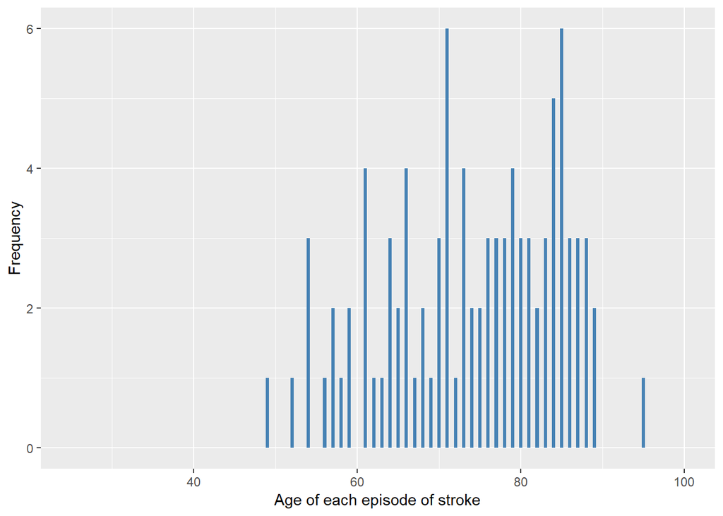

#### 2.1.4.4 Validation

|  | hedimst==0->0 | hedimst==1->1 | hedimst==-9->997 | hedimst==-8->998 |
| --- | --- | --- | --- | --- |
| BeforeH | 10851 | 183 | 7 | 9 |
| AfterH | 10851 | 183 | 7 | 9 |

### 2.1.5 Wave 5

#### 2.1.5.1 Study-specific variable description

[output not shown]

hedimst

| Sample size | Missing values |
| --- | --- |
| 10274 | 15 |

Category

|  | 0 | 1 |
| --- | --- | --- |
| Frequency | 10110.0 | 149.00 |
| Percentage | 98.4 | 1.45 |

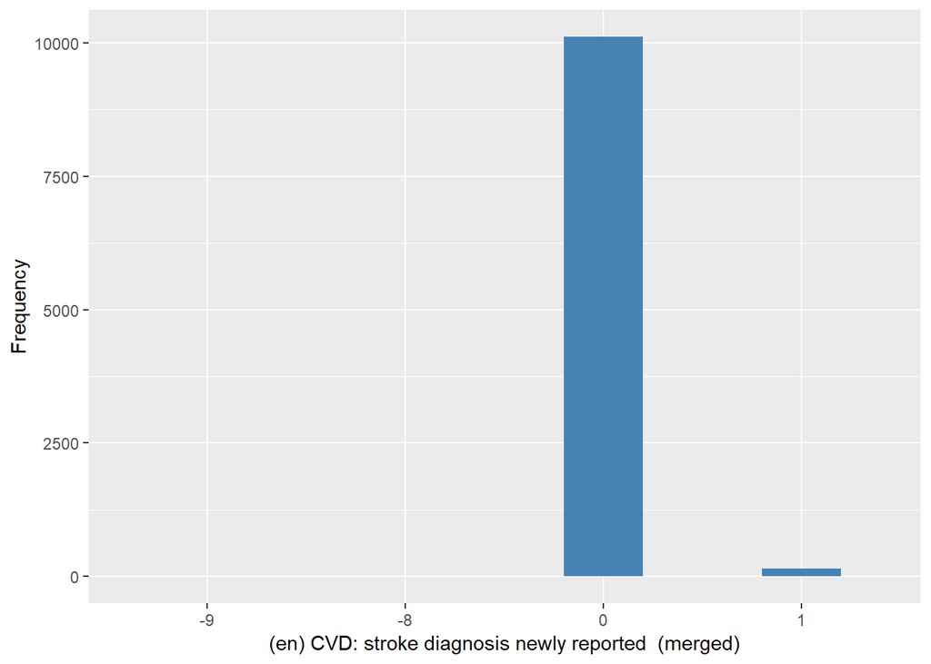

heagery

| Sample size | Missing values |
| --- | --- |
| 10274 | 10177 |

Summary

| Min. | 1st Qu. | Median | Mean | 3rd Qu. | Max. |
| --- | --- | --- | --- | --- | --- |
| 1979 | 2008 | 2009 | 2008 | 2010 | 2011 |

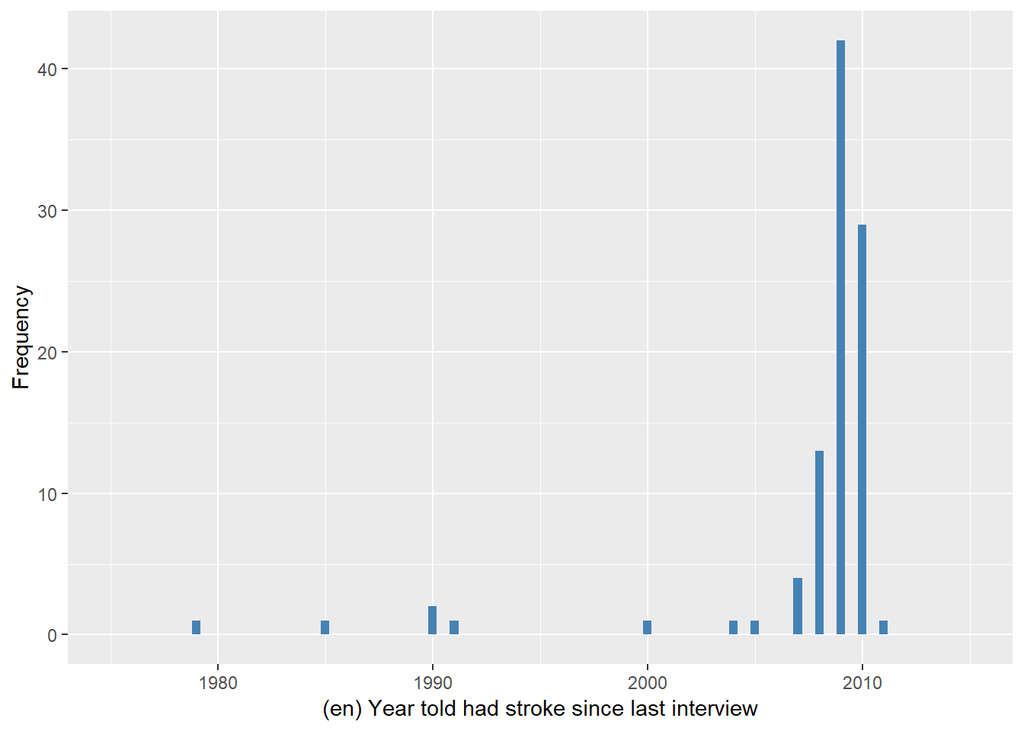

ybirth

| Sample size | Missing values |
| --- | --- |
| 10274 | 0 |

Summary

| Min. | 1st Qu. | Median | Mean | 3rd Qu. | Max. |
| --- | --- | --- | --- | --- | --- |
| 1908 | 1936 | 1945 | 1943 | 1951 | 1984 |

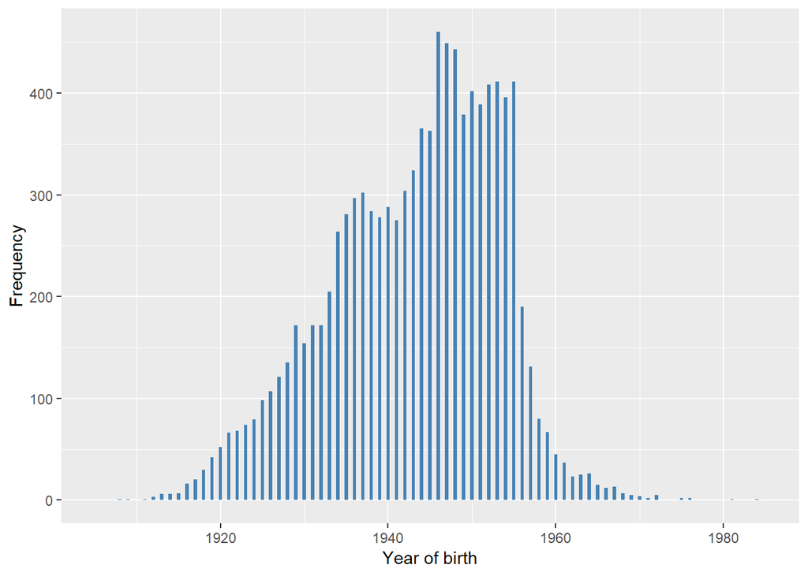

#### 2.1.5.2 Harmonisation algorithm

To compute `stroke` from the study-specific variable it has to be recoded as follows:

- `hedimst == 1 into 1`
- `hedimst == -9 into 997`
- `hedimst == -8 into 998`
- `hedimst == 0 into 0`

To compute `stroke_age` from the study-specific variable it has to be recoded as follows:

- `if stroke == 1, stroke_age = heagery - ybirth`
- `if stroke == 0, stroke_age = 996`
- `-9 into 997`
- `-8 into 998`
- `-1 into 996`
- `otherwise, stroke_age = 999`

**R script:**

```r
# Categorical variable harmonization
ELSA_ds_w5 <- tibble(id = ELSA_w5$id)
ELSA_ds_w5$stroke <- car::recode(ELSA_w5$hedimst, "-8=998;-9=997")

# Continuous variable harmonization
ELSA_ds_w5$stroke_age <- rep(999, length(ELSA_w5$id))
ELSA_ds_w5$stroke_age[which(ELSA_ds_w5$stroke == 0)] <- 996
ELSA_ds_w5$stroke_age[which(ELSA_ds_w5$stroke == 1 & !ELSA_w5$heagery %in% c(-1,
    -8, -9))] <- ELSA_w5$heagery[which(ELSA_ds_w5$stroke == 1 & !ELSA_w5$heagery %in%
    c(-1, -8, -9))] - ELSA_w5$ybirth[which(ELSA_ds_w5$stroke == 1 & !ELSA_w5$heagery %in%
    c(-1, -8, -9))]
ELSA_ds_w5$stroke_age <- car::recode(ELSA_ds_w5$stroke_age, "-1=996;-8=998;-9=997;NA=999")
```

#### 2.1.5.3 Statistics of the new harmonized variable

Stroke

| Sample size | Missing values |
| --- | --- |
| 10274 | 15 |

Category

|  | 0 | 1 |
| --- | --- | --- |
| Frequency | 10110.0 | 149.00 |
| Percentage | 98.4 | 1.45 |

Type of missing

|  | 991 | 992 | 993 | 994 | 995 | 996 | 997 | 998 | 999 | NA |
| --- | --- | --- | --- | --- | --- | --- | --- | --- | --- | --- |
| Frequency | 0 | 0 | 0 | 0 | 0 | 0 | 4.00 | 11.00 | 0 | 0 |
| Percentage | 0 | 0 | 0 | 0 | 0 | 0 | 0.04 | 0.11 | 0 | 0 |

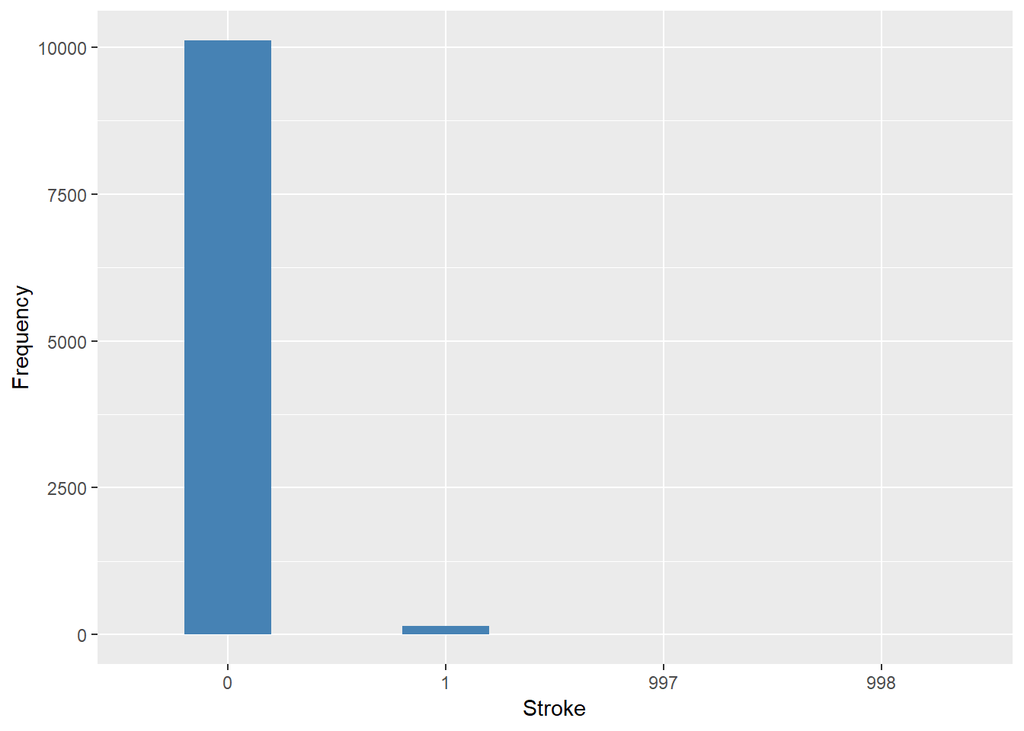

Age of each episode of stroke

| Sample size | Missing values |
| --- | --- |
| 10274 | 10177 |

Values

|  | No-missings | 991 | 992 | 993 | 994 | 995 | 996 | 997 | 998 | 999 | NA |
| --- | --- | --- | --- | --- | --- | --- | --- | --- | --- | --- | --- |
| Frequency | 97.00 | 0 | 0 | 0 | 0 | 0 | 10110.0 | 0 | 0 | 67.00 | 0 |
| Percentage | 0.94 | 0 | 0 | 0 | 0 | 0 | 98.4 | 0 | 0 | 0.65 | 0 |

Summary

| Min. | 1st Qu. | Median | Mean | 3rd Qu. | Max. |
| --- | --- | --- | --- | --- | --- |
| 33 | 65 | 74 | 72.33 | 81 | 94 |

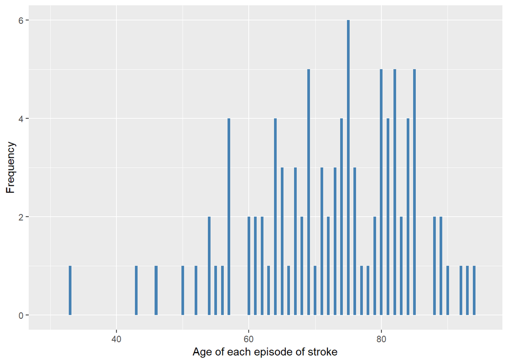

#### 2.1.5.4 Validation

|  | hedimst==0->0 | hedimst==1->1 | hedimst==-9->997 | hedimst==-8->998 |
| --- | --- | --- | --- | --- |
| BeforeH | 10110 | 149 | 4 | 11 |
| AfterH | 10110 | 149 | 4 | 11 |

### 2.1.6 Wave 6

#### 2.1.6.1 Study-specific variable description

[output not shown]

hedimst

| Sample size | Missing values |
| --- | --- |
| 10601 | 11 |

Category

|  | 0 | 1 |
| --- | --- | --- |
| Frequency | 10432.00 | 158.00 |
| Percentage | 98.41 | 1.49 |

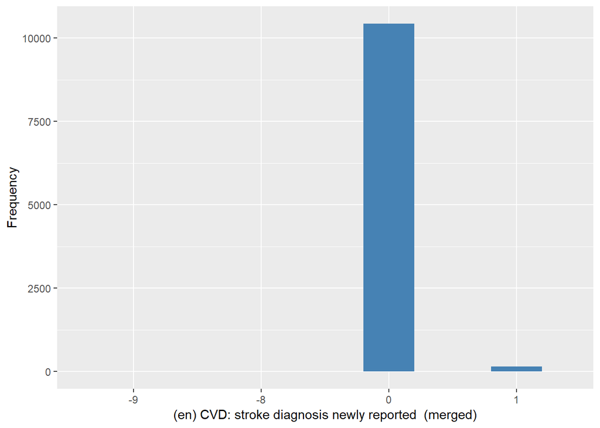

HeAgeRY

| Sample size | Missing values |
| --- | --- |
| 10601 | 10503 |

Summary

| Min. | 1st Qu. | Median | Mean | 3rd Qu. | Max. |
| --- | --- | --- | --- | --- | --- |
| 1985 | 2011 | 2012 | 2010 | 2012 | 2013 |

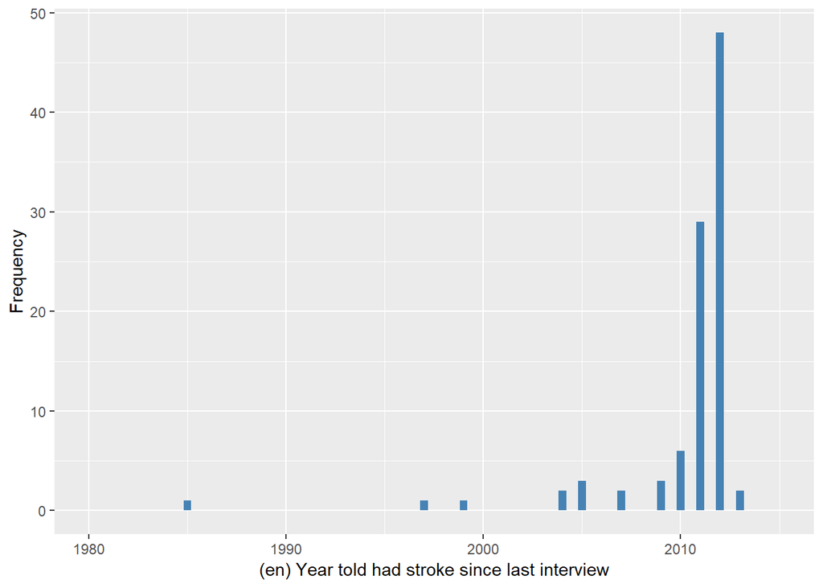

ybirth

| Sample size | Missing values |
| --- | --- |
| 10601 | 0 |

Summary

| Min. | 1st Qu. | Median | Mean | 3rd Qu. | Max. |
| --- | --- | --- | --- | --- | --- |
| 1911 | 1938 | 1946 | 1945 | 1953 | 1984 |

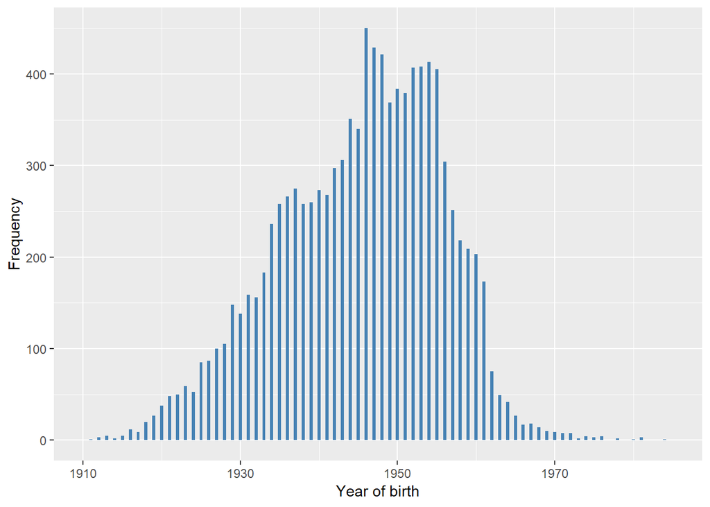

#### 2.1.6.2 Harmonisation algorithm

To compute `stroke` from the study-specific variable it has to be recoded as follows:

- `hedimst == 1 into 1`
- `hedimst == -9 into 997`
- `hedimst == -8 into 998`
- `hedimst == 0 into 0`

To compute `stroke_age` from the study-specific variable it has to be recoded as follows:

- `if stroke == 1, stroke_age = HeAgeRY - ybirth`
- `if stroke == 0, stroke_age = 996`
- `-9 into 997`
- `-8 into 998`
- `-1 into 996`
- `otherwise, stroke_age = 999`

**R script:**

```r
# Categorical variable harmonization
ELSA_ds_w6 <- tibble(id = ELSA_w6$id)
ELSA_ds_w6$stroke <- car::recode(ELSA_w6$hedimst, "-8=998;-9=997")

# Continuous variable harmonization
ELSA_ds_w6$stroke_age <- rep(999, length(ELSA_w6$id))
ELSA_ds_w6$stroke_age[which(ELSA_ds_w6$stroke == 0)] <- 996
ELSA_ds_w6$stroke_age[which(ELSA_ds_w6$stroke == 1 & !ELSA_w6$HeAgeRY %in% c(-1,
    -8, -9))] <- ELSA_w6$HeAgeRY[which(ELSA_ds_w6$stroke == 1 & !ELSA_w6$HeAgeRY %in%
    c(-1, -8, -9))] - ELSA_w6$ybirth[which(ELSA_ds_w6$stroke == 1 & !ELSA_w6$HeAgeRY %in%
    c(-1, -8, -9))]
ELSA_ds_w6$stroke_age <- car::recode(ELSA_ds_w6$stroke_age, "-1=996;-8=998;-9=997;NA=999")
```

#### 2.1.6.3 Statistics of the new harmonized variable

Stroke

| Sample size | Missing values |
| --- | --- |
| 10601 | 11 |

Category

|  | 0 | 1 |
| --- | --- | --- |
| Frequency | 10432.00 | 158.00 |
| Percentage | 98.41 | 1.49 |

Type of missing

|  | 991 | 992 | 993 | 994 | 995 | 996 | 997 | 998 | 999 | NA |
| --- | --- | --- | --- | --- | --- | --- | --- | --- | --- | --- |
| Frequency | 0 | 0 | 0 | 0 | 0 | 0 | 4.00 | 7.00 | 0 | 0 |
| Percentage | 0 | 0 | 0 | 0 | 0 | 0 | 0.04 | 0.07 | 0 | 0 |

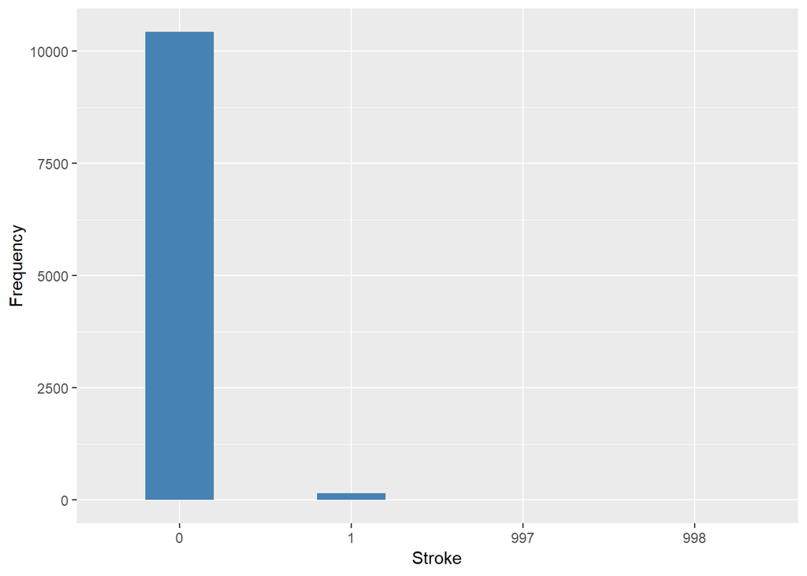

Age of each episode of stroke

| Sample size | Missing values |
| --- | --- |
| 10601 | 10503 |

Values

|  | No-missings | 991 | 992 | 993 | 994 | 995 | 996 | 997 | 998 | 999 | NA |
| --- | --- | --- | --- | --- | --- | --- | --- | --- | --- | --- | --- |
| Frequency | 98.00 | 0 | 0 | 0 | 0 | 0 | 10432.00 | 0 | 0 | 71.00 | 0 |
| Percentage | 0.92 | 0 | 0 | 0 | 0 | 0 | 98.41 | 0 | 0 | 0.67 | 0 |

Summary

| Min. | 1st Qu. | Median | Mean | 3rd Qu. | Max. |
| --- | --- | --- | --- | --- | --- |
| 54 | 67 | 75 | 73.84 | 80 | 93 |

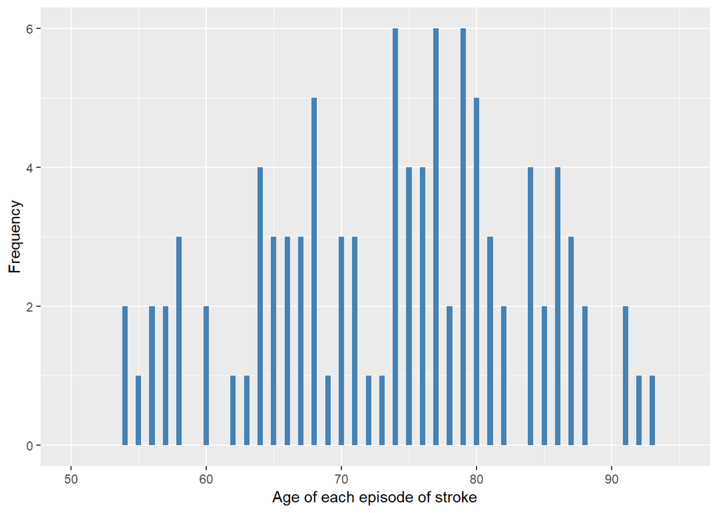

#### 2.1.6.4 Validation

|  | hedimst==0->0 | hedimst==1->1 | hedimst==-9->997 | hedimst==-8->998 |
| --- | --- | --- | --- | --- |
| BeforeH | 10432 | 158 | 4 | 7 |
| AfterH | 10432 | 158 | 4 | 7 |

### 2.1.7 Wave 7

#### 2.1.7.1 Study-specific variable description

[output not shown]

hedimst

| Sample size | Missing values |
| --- | --- |
| 9666 | 6 |

Category

|  | 0 | 1 |
| --- | --- | --- |
| Frequency | 9522.00 | 138.00 |
| Percentage | 98.51 | 1.43 |

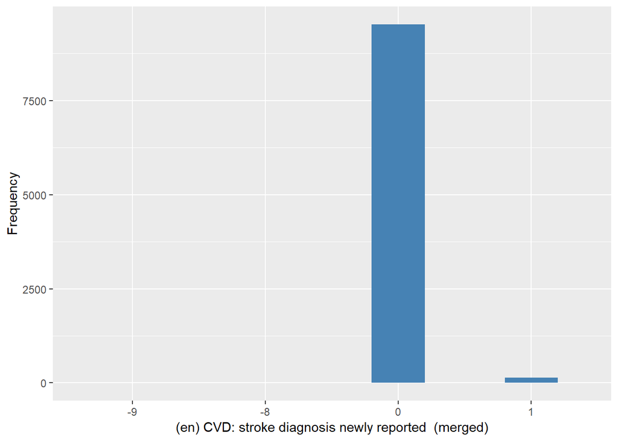

HeAgeRY

| Sample size | Missing values |
| --- | --- |
| 9666 | 9569 |

Summary

| Min. | 1st Qu. | Median | Mean | 3rd Qu. | Max. |
| --- | --- | --- | --- | --- | --- |
| 2002 | 2013 | 2013 | 2013 | 2014 | 2015 |

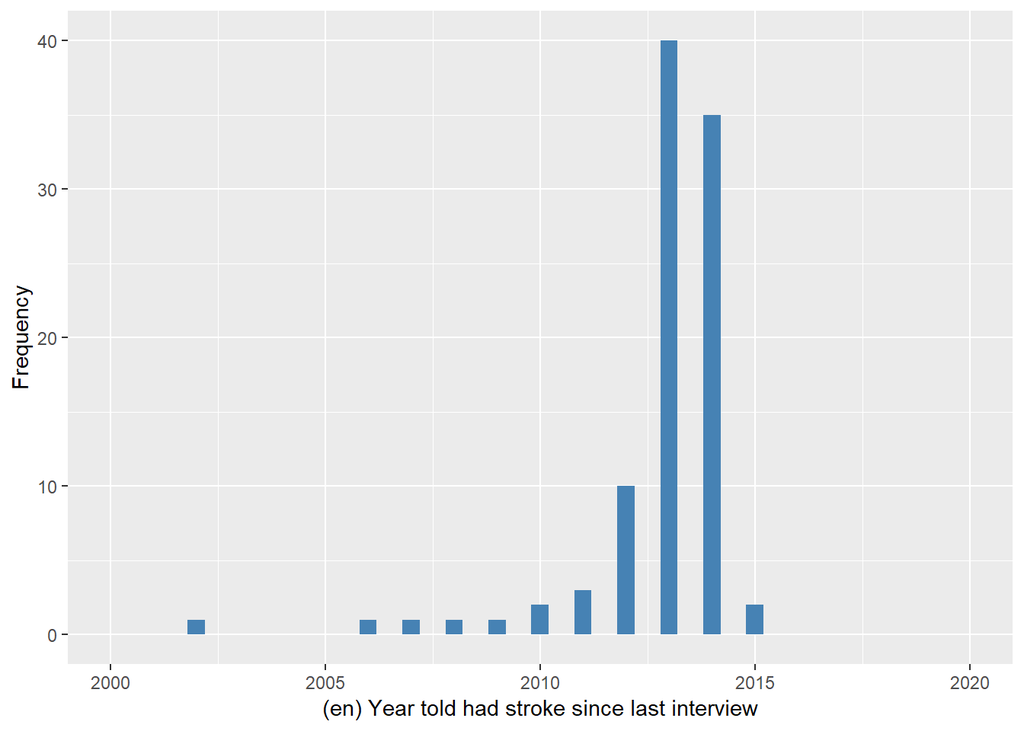

ybirth

| Sample size | Missing values |
| --- | --- |
| 9666 | 0 |

Summary

| Min. | 1st Qu. | Median | Mean | 3rd Qu. | Max. |
| --- | --- | --- | --- | --- | --- |
| 1911 | 1939 | 1947 | 1946 | 1954 | 1985 |

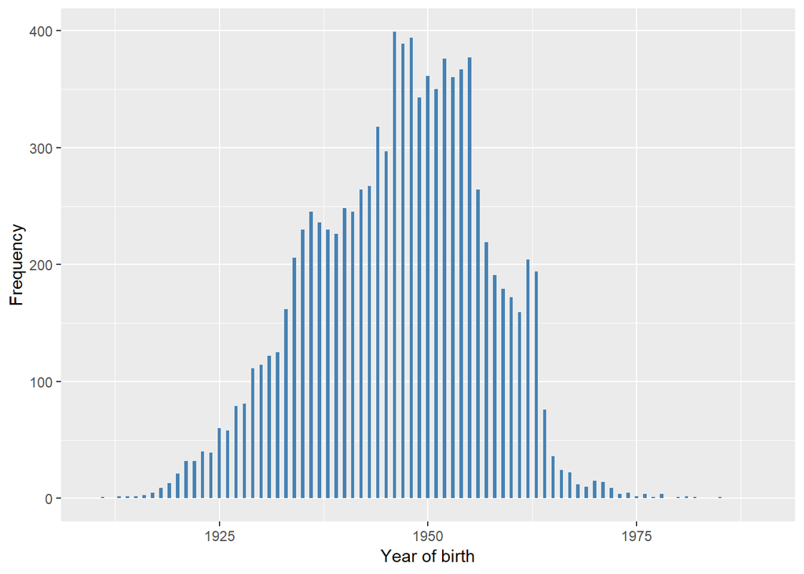

#### 2.1.7.2 Harmonisation algorithm

To compute `stroke` from the study-specific variable it has to be recoded as follows:

- `hedimst == 1 into 1`
- `hedimst == -9 into 997`
- `hedimst == -8 into 998`
- `hedimst == 0 into 0`

To compute `stroke_age` from the study-specific variable it has to be recoded as follows:

- `if stroke == 1, stroke_age = HeAgeRY - ybirth`
- `if stroke == 0, stroke_age = 996`
- `-9 into 997`
- `-8 into 998`
- `-1 into 996`
- `otherwise, stroke_age = 999`

**R script:**

```r
# Categorical variable harmonization
ELSA_ds_w7 <- tibble(id = ELSA_w7$id)
ELSA_ds_w7$stroke <- car::recode(ELSA_w7$hedimst, "-8=998;-9=997")

# Continuous variable harmonization
ELSA_ds_w7$stroke_age <- rep(999, length(ELSA_w7$id))
ELSA_ds_w7$stroke_age[which(ELSA_ds_w7$stroke == 0)] <- 996
ELSA_ds_w7$stroke_age[which(ELSA_ds_w7$stroke == 1 & !ELSA_w7$HeAgeRY %in% c(-1,
    -8, -9))] <- ELSA_w7$HeAgeRY[which(ELSA_ds_w7$stroke == 1 & !ELSA_w7$HeAgeRY %in%
    c(-1, -8, -9))] - ELSA_w7$ybirth[which(ELSA_ds_w7$stroke == 1 & !ELSA_w7$HeAgeRY %in%
    c(-1, -8, -9))]
ELSA_ds_w7$stroke_age <- car::recode(ELSA_ds_w7$stroke_age, "-1=996;-8=998;-9=997;NA=999")
```

#### 2.1.7.3 Statistics of the new harmonized variable

Stroke

| Sample size | Missing values |
| --- | --- |
| 9666 | 6 |

Category

|  | 0 | 1 |
| --- | --- | --- |
| Frequency | 9522.00 | 138.00 |
| Percentage | 98.51 | 1.43 |

Type of missing

|  | 991 | 992 | 993 | 994 | 995 | 996 | 997 | 998 | 999 | NA |
| --- | --- | --- | --- | --- | --- | --- | --- | --- | --- | --- |
| Frequency | 0 | 0 | 0 | 0 | 0 | 0 | 1.00 | 5.00 | 0 | 0 |
| Percentage | 0 | 0 | 0 | 0 | 0 | 0 | 0.01 | 0.05 | 0 | 0 |

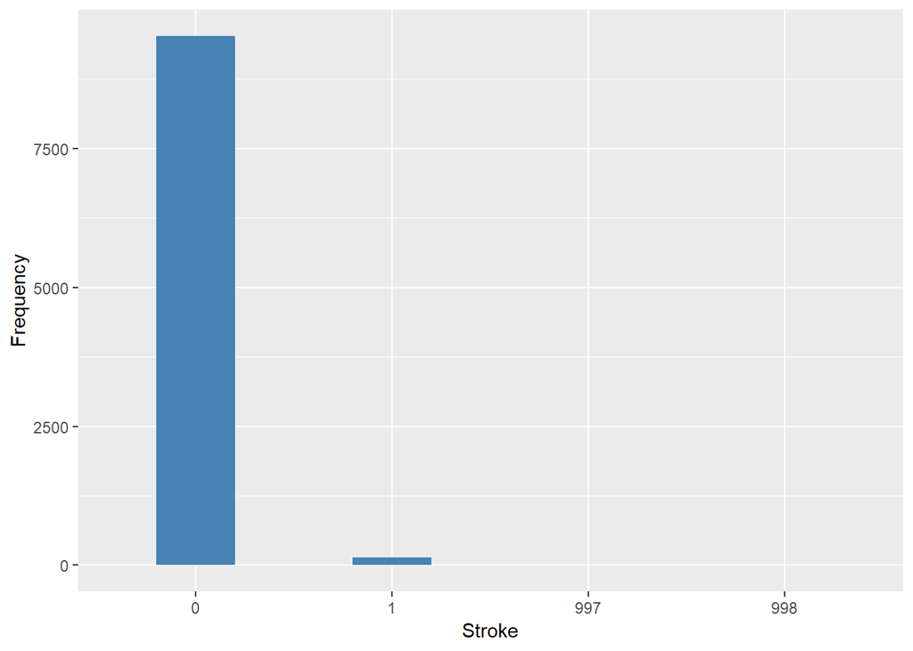

Age of each episode of stroke

| Sample size | Missing values |
| --- | --- |
| 9666 | 9569 |

Values

|  | No-missings | 991 | 992 | 993 | 994 | 995 | 996 | 997 | 998 | 999 | NA |
| --- | --- | --- | --- | --- | --- | --- | --- | --- | --- | --- | --- |
| Frequency | 97 | 0 | 0 | 0 | 0 | 0 | 9522.00 | 0 | 0 | 47.00 | 0 |
| Percentage | 1 | 0 | 0 | 0 | 0 | 0 | 98.51 | 0 | 0 | 0.49 | 0 |

Summary

| Min. | 1st Qu. | Median | Mean | 3rd Qu. | Max. |
| --- | --- | --- | --- | --- | --- |
| 42 | 66 | 74 | 73.23 | 80 | 93 |

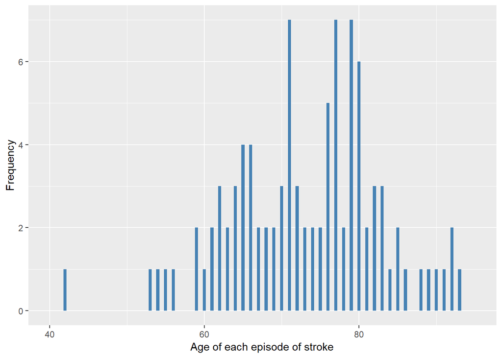

#### 2.1.7.4 Validation

|  | hedimst==0->0 | hedimst==1->1 | hedimst==-9->997 | hedimst==-8->998 |
| --- | --- | --- | --- | --- |
| BeforeH | 9522 | 138 | 1 | 5 |
| AfterH | 9522 | 138 | 1 | 5 |

## 2.2 Descriptive statistics of the harmonised variable `stroke` accross populations and waves

Two tables are generated:

1. Percentages of categories in each harmonised variable.
2. Frequencies and percentages of individuals with different trajectories. To avoid too large table, Only trajectories with percentages larger than 0.3 are shown.

Stroke

| val | label | W1 | W2 | W3 | W4 | W5 | W6 | W7 |
| --- | --- | --- | --- | --- | --- | --- | --- | --- |
| 0 | No | 95.66 | 98.1 | 98.81 | 98.2 | 98.4 | 98.41 | 98.51 |
| 1 | Yes | 4.26 | 1.8 | 1.14 | 1.66 | 1.45 | 1.49 | 1.43 |
| 991 | CAPI interviewer error | 0 | 0 | 0 | 0 | 0 | 0 | 0 |
| 992 | Impute | 0 | 0 | 0 | 0 | 0 | 0 | 0 |
| 993 | Disable to measure | 0 | 0 | 0 | 0 | 0 | 0 | 0 |
| 994 | Not attempt not done | 0 | 0 | 0 | 0 | 0 | 0 | 0 |
| 995 | Does not answer | 0 | 0 | 0 | 0 | 0 | 0 | 0 |
| 996 | Not applicable | 0 | 0 | 0.05 | 0 | 0 | 0 | 0 |
| 997 | Refuse | 0.02 | 0.01 | 0 | 0.06 | 0.04 | 0.04 | 0.01 |
| 998 | Do not know | 0.05 | 0.08 | 0 | 0.08 | 0.11 | 0.07 | 0.05 |
| 999 | Missing | 0 | 0 | 0 | 0 | 0 | 0 | 0 |
| NA | NA | 0 | 0 | 0 | 0 | 0 | 0 | 0 |
| n | sample size | 12099 | 9432 | 9771 | 11050 | 10274 | 10601 | 9666 |

|  | val | frq | raw.prc |
| --- | --- | --- | --- |
| 1 | 0000000 | 4051 | 21.91 |
| 3 | 000000NA | 592 | 3.20 |
| 7 | 00000NA0 | 69 | 0.37 |
| 9 | 00000NANA | 420 | 2.27 |
| 17 | 0000NA00 | 63 | 0.34 |
| 23 | 0000NANANA | 546 | 2.95 |
| 35 | 000NA000 | 115 | 0.62 |
| 36 | 000NA00NA | 58 | 0.31 |
| 48 | 000NANANANA | 840 | 4.54 |
| 64 | 00NA0000 | 111 | 0.60 |
| 91 | 00NANANANANA | 1186 | 6.41 |
| 114 | 0NA00000 | 93 | 0.50 |
| 134 | 0NA0NANANANA | 107 | 0.58 |
| 143 | 0NANA0000 | 69 | 0.37 |
| 169 | 0NANANANANANA | 1940 | 10.49 |
| 170 | 1000000 | 73 | 0.39 |
| 209 | 10NANANANANA | 63 | 0.34 |
| 240 | 1NANANANANANA | 143 | 0.77 |
| 267 | NANA00000 | 852 | 4.61 |
| 269 | NANA0000NA | 114 | 0.62 |
| 271 | NANA000NANA | 87 | 0.47 |
| 280 | NANA00NANANA | 119 | 0.64 |
| 283 | NANA0NA000 | 57 | 0.31 |
| 293 | NANA0NANANANA | 304 | 1.64 |
| 303 | NANANA0000 | 1649 | 8.92 |
| 305 | NANANA000NA | 243 | 1.31 |
| 310 | NANANA00NANA | 179 | 0.97 |
| 321 | NANANA0NANANA | 348 | 1.88 |
| 332 | NANANANA000 | 80 | 0.43 |
| 340 | NANANANANA00 | 924 | 5.00 |
| 342 | NANANANANA0NA | 266 | 1.44 |
| 346 | NANANANANANA0 | 506 | 2.74 |

## 2.3 Summary of descriptive statistics of the harmonised variable `stroke_age` accross populations and waves

Age of each episode of stroke

| stroke_age | W1 | W2 | W3 | W4 | W5 | W6 | W7 |
| --- | --- | --- | --- | --- | --- | --- | --- |
| Min. | 16 | 53 | 53 | 49 | 33 | 54 | 42 |
| 1st Qu. | 59 | 67 | 66 | 66 | 65 | 67 | 66 |
| Median | 68 | 74 | 73.5 | 75 | 74 | 75 | 74 |
| Mean | 66.8 | 73.83 | 73.66 | 73.95 | 72.33 | 73.84 | 73.23 |
| 3rd Qu. | 76 | 81 | 81.25 | 83 | 81 | 80 | 80 |
| Max. | 92 | 91 | 93 | 95 | 94 | 93 | 93 |
| No-missings | 395 | 158 | 88 | 95 | 97 | 98 | 97 |
| 991 | 0 | 0 | 0 | 0 | 0 | 0 | 0 |
| 992 | 0 | 0 | 0 | 0 | 0 | 0 | 0 |
| 993 | 0 | 0 | 0 | 0 | 0 | 0 | 0 |
| 994 | 0 | 0 | 0 | 0 | 0 | 0 | 0 |
| 995 | 0 | 0 | 0 | 0 | 0 | 0 | 0 |
| 996 | 11693 | 9253 | 9655 | 10851 | 10110 | 10432 | 9522 |
| 997 | 0 | 0 | 0 | 0 | 0 | 0 | 0 |
| 998 | 2 | 0 | 0 | 0 | 0 | 0 | 0 |
| 999 | 9 | 21 | 28 | 104 | 67 | 71 | 47 |
| NA | 0 | 0 | 0 | 0 | 0 | 0 | 0 |
| sample size | 12099 | 9432 | 9771 | 11050 | 10274 | 10601 | 9666 |

# 3 Quality estimation

No comments